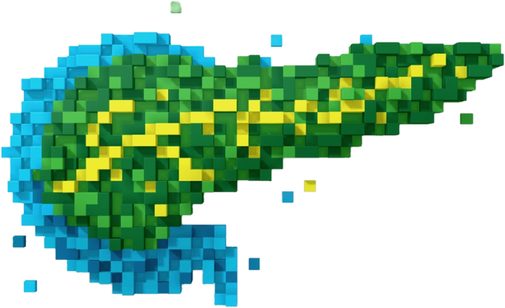

PanKbase Annual PIs Meeting

# 2026 Annual Retreat

Michigan League · Ann Arbor, Michigan

Day 1 November 12, 2026 • 8:15 AM – 6:00 PM

Day 2 November 13, 2026 • 8:15 AM – 2:00 PM

Venue Michigan League, Vandenberg Room · 911 N University Ave, Ann Arbor

Apple / iCal Google Calendar Outlook 365 Outlook.com Download .ics

About the Meeting

## Meeting Goals

Review progress, accomplishments, and lessons learned

Strengthen team building, communication, and relationships across PanKbase

Strengthen scientific and operational integration across PanKbase

Identify emerging scientific and data science opportunities

Align on priorities for the coming year

Translate priorities into concrete actions, responsibilities, and milestones

Michigan League

## Venue Maps & Parking

All meeting sessions take place at the **Michigan League**, 911 N University Ave, Ann Arbor, MI 48109. Use the tabs below for walking routes from the conference hotels, nearby parking, and building floor plans. Starred rooms are where sessions take place.

[figure not shown]

🚶 From Graduate by Hilton

**About 7 min · 0.3 mi.** Head east on E Huron St past N State and N Thayer, cut south to E Washington St, then follow the Ingalls Mall green south to the Michigan League.

🚶 From The Vanguard

**About 8 min · 0.3 mi.** Walk south on Glen Ave to E Huron St, take the diagonal path across the green to Fletcher St, then head south on Fletcher to the Michigan League.

🌧 November Weather

Mid-November in Ann Arbor is often cold and damp. Bring a warm coat and umbrella; rideshares are an easy alternative.

Once inside, breakfast and morning sessions are in the **Vandenberg Room** on the second floor. See the floor plan tabs for room locations.

[figure not shown]

🅿 Lot N4

On S. Thayer St between E. Liberty and E. Washington. Closest structure to Michigan League — approximately a 3-minute walk. Visitor pay stations available.

🅿 Lot N13

On Fletcher St near E. Washington. Approximately a 5-minute walk to Michigan League. Additional visitor parking option.

🚶 Walking from Hotels

Both conference hotels are a 7–8 minute walk. See the *Getting to the Michigan League* tab for routes.

Parking on campus is limited. Visit pts.umich.edu for current availability and rates. Arrive early on meeting days.

[figure not shown]

Room 4

⭐

⭐**Room 4** — First Floor (enter via N. University Ave or Ingalls Mall entrance)

The N. University Ave entrance is on the south side of the building and is the most accessible from both parking lots and the hotels.

[figure not shown]

Vandenberg

⭐

⭐**Vandenberg Room** — Second Floor (take elevator or main staircase from lobby)

Vandenberg is a large meeting/event room on the south side of the second floor. An elevator is available from the main lobby.

[figure not shown]

Room A

⭐

⭐**Room A** — Third Floor (leftmost room in the central corridor)

Room A is on the third floor. Use the elevator near the main lobby and follow the corridor to the left.

Program

## Agenda

**Day 1 objective:** Bring the PanKbase team together around a shared understanding of program progress, accomplishments, challenges, and Working Group activities. Build on this common foundation to strengthen team connections, identify gaps and emerging opportunities, and promote productive collaboration across the program.

[output not shown]

**Day 2 objective:** Build on Day 1 discussions to shape PanKbase’s strategic direction. Share Working Group updates, celebrate 2025 OP Fund awardees, and align program leadership on key scientific, platform, and community priorities for the coming year.

[output not shown]

Keynote & Invited Talks

## Featured Speakers

Keynote Lecture

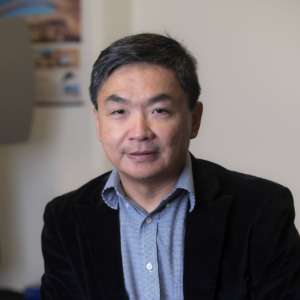

Dr. Chen Li

University of California, Irvine

Invited Virtual Talks

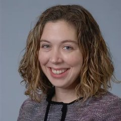

Dr. Emily Sims

Indiana University School of Medicine

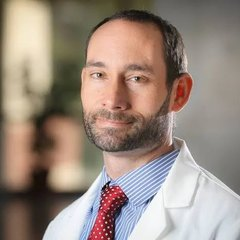

Dr. Todd Brusko

University of Florida

Accommodations

## Recommended Hotels

⏰ **Book by October 21, 2026** to reserve your room in the conference block. Both hotels are a short walk from Michigan League and located in the heart of downtown Ann Arbor.

Marriott Family of Hotels

The Vanguard Ann Arbor

201 Glen Ave  
Ann Arbor, MI 48104

📅 Book Conference Rate [↗ View on Google Maps](https://maps.google.com/?q=The+Vanguard+Ann+Arbor+201+Glen+Ave+Ann+Arbor+MI) [🚶 Directions to Michigan League](https://www.google.com/maps/dir/201+Glen+Ave,+Ann+Arbor,+MI+48104/Michigan+League,+911+N+University+Ave,+Ann+Arbor,+MI+48109)

Hilton Family of Hotels

The Graduate Ann Arbor

615 E Huron St  
Ann Arbor, MI 48104

[📅 Book Conference Rate](https://book.passkey.com/event/51317718/owner/50919754/home) [↗ View on Google Maps](https://maps.google.com/?q=The+Graduate+Ann+Arbor+615+E+Huron+St+Ann+Arbor+MI) [🚶 Directions to Michigan League](https://www.google.com/maps/dir/615+E+Huron+St,+Ann+Arbor,+MI+48104/Michigan+League,+911+N+University+Ave,+Ann+Arbor,+MI+48109)

Transportation

## Getting to Ann Arbor

The closest major airport is **Detroit Metropolitan Wayne County Airport (DTW)**, approximately 45 minutes from Ann Arbor by car. Several ground transportation options are available from both terminals.

Rideshare

Uber & Lyft

**McNamara Terminal:** Level 4 of the McNamara Parking Garage — cross the skybridge from the terminal.  
**Evans Terminal:** Level 1 of the Evans Parking Garage — cross the skybridge.  
Collect baggage, follow Ground Transportation/Skybridge signs, and check your app for the exact pickup bay.

Taxi & Luxury Sedan

Metro Cars / Metro Cab

Officially serviced by [Metro Cars](https://www.metrocars.com/) and Metro Cab. Both dispatch from the Ground Transportation Center (Level 4 at McNamara; upper Level 4 at Evans).  
Metro Cab: (734) 997-6500  
Metro Cars: (800) 456-1701  
On-site kiosks also available at both terminals.

Coach Bus — Recommended

Michigan Flyer / AirRide

[Michigan Flyer](https://www.michiganflyer.com/) offers direct nonstop motorcoach service between DTW and downtown Ann Arbor. Affordable and convenient — a great option for solo travelers. Boards from the Ground Transportation Centers at both terminals.

Express Bus

Detroit Air Xpress (DAX)

[DAX](https://www.dax-bus.com/) provides nonstop express bus service to downtown Detroit. Pick up at Evans Terminal (Stalls 1–2) or McNamara Terminal (Departures Level, near Door 1).

Public Transit

SMART Bus

[SMART Bus](https://www.smartbus.org/) routes including FAST Michigan Route 261 and Route 125 serve both terminal Ground Transportation Centers, connecting DTW to Detroit and nearby communities.

Rental Car

On-Site Rental Shuttles

Off-site rental car courtesy shuttles pick up directly from the Ground Transportation Centers at both terminals. All major rental car companies are represented. A free inter-terminal shuttle also runs every 10 minutes between McNamara and Evans if needed.

Ann Arbor

## Things to Do

Ann Arbor is a vibrant university city with a packed cultural calendar, distinctive local shops, and an exceptional dining scene. Below you’ll find events happening during your stay, along with standing recommendations for evening exploration.

Events During Your Stay

Wednesday, November 11 (Arrival day)

Concert

The Glenn Miller Orchestra

7:00 PM — Michigan Theater, 603 E Liberty St — ~$88 — Main floor seating recommended (no elevator to balcony)

Sports

Michigan Wolverines Women’s Volleyball vs. Ohio State

Evening — Cliff Keen Arena, 616 E Hoover Ave — Tickets via Michigan Athletics

Thursday, November 12 (Evening, after the meeting)

Arts

Penny Stamps Speaker Series — Voices of Dissent

5:30 PM — Michigan Theater — Dramatic reading with David Strathairn, Allison Moorer & Thornetta Davis — [Tickets via Penny Stamps Series](https://stamps.umich.edu/penny-stamps)

Music

Béla Fleck — My Bluegrass Heart

6:30 PM — [The Ark](https://theark.org/), 316 S Main St — Tickets required; purchase via The Ark website

Lecture

The Legacy of President Ford’s Signature — Kathleen Kornahrens

6:30 PM — Gerald R. Ford Presidential Library, 1000 Beal Ave — Free public event

Music

Jazz Oratorio: Middle Passage — Stephen Rush

7:30 PM — Kerrytown Concert House, 415 N 4th Ave — Large-scale jazz oratorio; advance reservation recommended

Sports

Michigan Wolverines Hockey vs. Penn State

Yost Ice Arena, 1116 S State St — Tickets via [Michigan Athletics](https://mgoblue.com/)

Friday, November 13 (Evening, after the meeting)

Concert

Mozart’s Requiem — Ann Arbor Symphony & UMS Choral Union

7:30 PM — Hill Auditorium, 825 N University Ave — Check [University Musical Society](https://ums.org/) for tickets

Theatre

Othello — U-M School of Music, Theatre & Dance

U-M SMTD, 1100 Baits Dr — Shakespeare performed by student and faculty artists — [Tickets via SMTD](https://smtd.umich.edu/)

Comedy

Josh Adams Live at HOMES Campus

7:30 PM — HOMES Campus, 112 Jackson Plaza — Detroit comedian Josh Adams — [Tickets via Tixfox](https://tixfox.co/e/4XVNGeAZ7Z)

Attractions & Museums

[University of Michigan Museum of Art](https://umma.umich.edu/) [UM Museum of Natural History](https://lsa.umich.edu/ummnh)

Ann Arbor Hands-On Museum

Nichols Arboretum

Michigan Theater

Michigan Stadium — The Big House

Gerald R. Ford Presidential Library

Nickels Arcade

⭐ Bon Bon Bon (in Nickels Arcade) — exceptional local chocolates, highly recommended

Kerrytown Market & Shops

Pinball Pete’s

Dining Highlights

Zingerman’s Deli

Detroit Filling Station (vegetarian)

Miss Kim’s

Ashley’s

Knight’s Steakhouse

Slurping Turtle

Sava’s

🏦 **November weather in Ann Arbor:** Expect temperatures in the low-to-mid 40s°F (5–8°C) with possible rain or light snow. Bring a warm coat, layers, and waterproof footwear. [Check the forecast closer to your trip ↗](https://weather.com/weather/tenday/l/Ann+Arbor+MI+USMI0014:1:US)

Practical Information

## Essentials

Urgent Care

HELLOMED Urgent Care — Central Campus

Lower Level, 625 E Liberty St Ste 10, Ann Arbor  
Walk-in and scheduled visits for non-life-threatening illness or injury.  
**Hours:** Mon 8:30 AM–1:00 PM · Tue 12–6 PM · Wed 8:30 AM–6:30 PM · Thu–Fri 9 AM–2 PM · Closed weekends

(734) 707-1904 [↗ Directions](https://maps.google.com/?q=625+E+Liberty+St+Ann+Arbor+MI)

Ann Arbor Urgent Care

1000 E Stadium Blvd, Ann Arbor  
Walk-in care, on-site lab, X-rays.  
**Hours:** Mon–Sun 9:00 AM – 9:00 PM

(734) 769-3333 [↗ Directions](https://maps.google.com/?q=1000+E+Stadium+Blvd+Ann+Arbor+MI)

Pharmacies

CVS Pharmacy

209 S State St — ~0.4 miles from venue (˜10-min walk)  
Full pharmacy, OTC medicine, grocery basics.  
**Hours:** Daily 8:00 AM – 11:00 PM

[↗ Directions](https://maps.google.com/?q=CVS+209+S+State+St+Ann+Arbor+MI)

Walgreens

317 S State St — next door to CVS, ~0.4 miles from venue  
**Hours:** Mon–Sat 7:00 AM – 10:00 PM · Sun 8:00 AM – 10:00 PM

[↗ Directions](https://maps.google.com/?q=Walgreens+317+S+State+St+Ann+Arbor+MI)

Forgot Something?

Target

231 S State St — in-store shopping, pickup, and no-contact delivery.  
**Hours:** Closes 10:00 PM

(734) 205-1869 [↗ Directions](https://maps.google.com/?q=Target+231+S+State+St+Ann+Arbor+MI)

Venue

Michigan League — 911 N University Ave, Ann Arbor, MI 48109

[↗ View on Google Maps](https://maps.google.com/?q=Michigan+League+911+N+University+Ave+Ann+Arbor+MI)